# Lab#7&8

Lab 7 Event selection optimization

In this lab, we will work with the high-pT LHC data.

Problem 1

Now we will try to plot histogram for mass feature in our data and evaluate expected significance without any event selection.

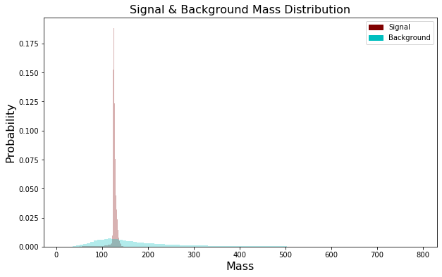

```python
import pickle
%matplotlib inline
import numpy as np
import matplotlib
import matplotlib.pyplot as plt
import matplotlib.patches as mpatches
from scipy import stats

infile = open ("higgs_100000_pt_1000_1200.pkl",'rb')
higgs = pickle.load(infile)

infile2 = open ("qcd_100000_pt_1000_1200.pkl",'rb')
qcd = pickle.load(infile2)

plt.rcParams["figure.figsize"] = (10, 6)

plt.hist(higgs['mass'][:], 100, color = 'maroon', density=True, alpha=0.3)
plt.hist(qcd['mass'][:], 100, color = 'c', density=True, alpha=0.3)
plt.xlabel('Mass', fontsize=16)
plt.ylabel('Probability', fontsize=16)
plt.title('Signal & Background Mass Distribution', fontsize=16)
maroon_patch = mpatches.Patch(color='maroon', label='Signal')
c_patch = mpatches.Patch(color='c', label='Background')
plt.legend(handles=[maroon_patch, c_patch])
```

In order to evaluate the significance, we will use poisson distribution and survival function. In this part, we will try to calculate the significance of getting 50 signal data and 2000 background data. We first calculate the probability.

```python
N_higgs = 50
N_qcd = 2000
prob = stats.poisson.sf(N_higgs + N_qcd,N_qcd)
sigma = stats.norm.isf(prob)
print("The significance calculated is", sigma)
com = N_higgs / np.sqrt(N_qcd)
print("The number of 𝑁𝐻𝑖𝑔𝑔𝑠/(√𝑁𝑄𝐶𝐷) is", com)
```

```
The significance calculated is 1.1282230087754423
The number of 𝑁𝐻𝑖𝑔𝑔𝑠/(√𝑁𝑄𝐶𝐷) is 1.118033988749895
```

Problem 2

```python
def mass_cuts (bottom, top):
    higgs_cut = 100000 - (len(higgs['mass'][bottom > higgs['mass']]) + len(higgs['mass'][top < higgs['mass']]))
    qcd_cut = 100000 - (len(qcd['mass'][bottom > qcd['mass']]) + len(qcd['mass'][top < qcd['mass']]))
    higgsratio = higgs_cut / len(higgs['mass'])
    qcdratio = qcd_cut / len(qcd['mass'])
    N_higgs = 50 * higgsratio
    N_qcd = 2000 * qcdratio
    sig = stats.norm.isf(stats.poisson.sf(N_higgs + N_qcd,N_qcd))
    return sig
```

```python
for i in range(130):
    sig = mass_cuts(i, 130)
    print([sig, i,130])
```

```
[1.4066910028815793, 0, 130]
[1.4066910028815793, 1, 130]
[1.4066910028815793, 2, 130]
[1.4066910028815793, 3, 130]
[1.4066910028815793, 4, 130]
[1.4066910028815793, 5, 130]
[1.4066910028815793, 6, 130]
[1.4066910028815793, 7, 130]
[1.4066910028815793, 8, 130]
[1.4066910028815793, 9, 130]
[1.4066910028815793, 10, 130]
[1.4066910028815793, 11, 130]
[1.407409945540205, 12, 130]
[1.407409945540205, 13, 130]
[1.407409945540205, 14, 130]
[1.407409945540205, 15, 130]
[1.407409945540205, 16, 130]
[1.407409945540205, 17, 130]
[1.407409945540205, 18, 130]
[1.4081289004320352, 19, 130]
[1.4081289004320352, 20, 130]
[1.4081289004320352, 21, 130]
[1.4088478675576204, 22, 130]
[1.4110048423423116, 23, 130]
[1.4110048423423116, 24, 130]
[1.4153191222965358, 25, 130]
[1.4189146921647795, 26, 130]
[1.4196338428620336, 27, 130]
[1.4239490041566367, 28, 130]
[1.42898391619023, 29, 130]
[1.4018163351957391, 30, 130]
[1.4082905608762946, 31, 130]
[1.4169244062035247, 32, 130]
[1.432757709799768, 33, 130]
[1.4142122871680742, 34, 130]
[1.4271736516502624, 35, 130]
[1.4107771148307102, 36, 130]
[1.43095196801645, 37, 130]
[1.4239189974260746, 38, 130]
[1.4147148537182885, 39, 130]
```

[output cut: 75 more lines]

```
[2.6463520050212552, 115, 130]
[2.7680698874627887, 116, 130]
[2.8424237969097903, 117, 130]
[2.9672492889753657, 118, 130]
[3.105267969084265, 119, 130]
[3.238935479641861, 120, 130]
[3.3753835931232627, 121, 130]
[3.516860733129746, 122, 130]
[3.680396455913725, 123, 130]
[3.9936223695208994, 124, 130]
[3.9714249315883174, 125, 130]
[3.029281106999288, 126, 130]
[2.087709714298047, 127, 130]
[1.4718224097982615, 128, 130]
[0.7236956034524948, 129, 130]
```

From the above results, we can see that for different mass cuts from 0 to 130 the significance increases first and then reach the peak point and starts decreasing. The peak value of siginificance we found is at mass cut from 124 to 130, and it is about 3.99, which is also much greater than the expected siginificance we found in problem 1.

Problem 3

For this problem, we will plot a stacked histogram of different features in our datasets and try if we can find another feature as discriminative as mass feature and identify additional feature to further imrpove expected signifiance.

SET A

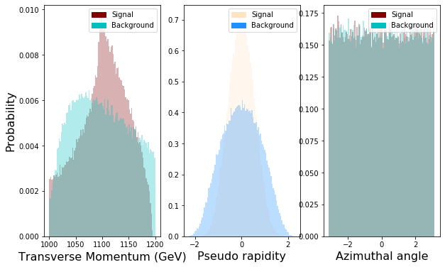

```python
fig, (ax1, ax2, ax3) = plt.subplots(1, 3)
ax1.hist(higgs['pt'][:], 100, color = 'maroon', density=True, alpha=0.3)
ax1.hist(qcd['pt'][:], 100, color = 'c', density=True, alpha=0.3)
ax1.set_xlabel('Transverse Momentum (GeV)', fontsize=16)
ax1.set_ylabel('Probability', fontsize=16)
maroon_patch = mpatches.Patch(color='maroon', label='Signal')
c_patch = mpatches.Patch(color='c', label='Background')
ax1.legend(handles=[maroon_patch, c_patch])

ax2.hist(higgs['eta'][:], 100, color = 'bisque', density=True, alpha=0.3)
ax2.hist(qcd['eta'][:], 100, color = 'dodgerblue', density=True, alpha=0.3)
ax2.set_xlabel('Pseudo rapidity', fontsize=16)
sig_patch = mpatches.Patch(color='bisque', label='Signal')
bcg_patch = mpatches.Patch(color='dodgerblue', label='Background')
ax2.legend(handles=[sig_patch, bcg_patch])

ax3.hist(higgs['phi'][:], 100, color = 'maroon', density=True, alpha=0.3)
ax3.hist(qcd['phi'][:], 100, color = 'c', density=True, alpha=0.3)
ax3.set_xlabel('Azimuthal angle', fontsize=16)
maroon_patch = mpatches.Patch(color='maroon', label='Signal')
c_patch = mpatches.Patch(color='c', label='Background')
ax3.legend(handles=[maroon_patch, c_patch])
```

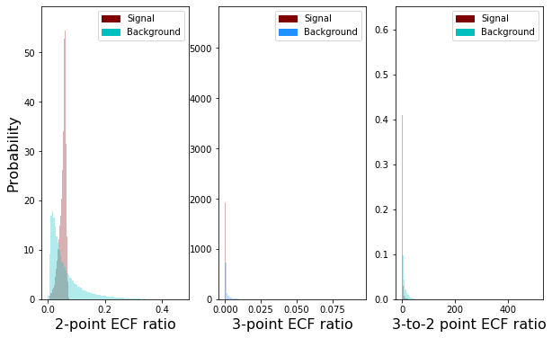

```python
fig, (ax1, ax2, ax3) = plt.subplots(1, 3)
ax1.hist(higgs['ee2'][:], 100, color = 'maroon', density=True, alpha=0.3)
ax1.hist(qcd['ee2'][:], 100, color = 'c', density=True, alpha=0.3)
ax1.set_xlabel('2-point ECF ratio', fontsize=16)
ax1.set_ylabel('Probability', fontsize=16)
maroon_patch = mpatches.Patch(color='maroon', label='Signal')
c_patch = mpatches.Patch(color='c', label='Background')
ax1.legend(handles=[maroon_patch, c_patch])

ax2.hist(higgs['ee3'][:], 100, color = 'maroon', density=True, alpha=0.3)
ax2.hist(qcd['ee3'][:], 100, color = 'dodgerblue', density=True, alpha=0.3)
ax2.set_xlabel('3-point ECF ratio', fontsize=16)
sig_patch = mpatches.Patch(color='maroon', label='Signal')
bcg_patch = mpatches.Patch(color='dodgerblue', label='Background')
ax2.legend(handles=[sig_patch, bcg_patch])

ax3.hist(higgs['d2'][:], 100, color = 'maroon', density=True, alpha=0.3)
ax3.hist(qcd['d2'][:], 100, color = 'c', density=True, alpha=0.3)
ax3.set_xlabel('3-to-2 point ECF ratio', fontsize=16)
maroon_patch = mpatches.Patch(color='maroon', label='Signal')
c_patch = mpatches.Patch(color='c', label='Background')
ax3.legend(handles=[maroon_patch, c_patch])
```

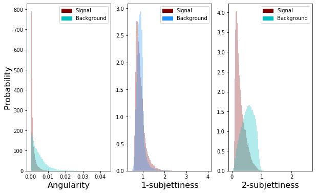

```python
fig, (ax1, ax2, ax3) = plt.subplots(1, 3)
ax1.hist(higgs['angularity'][:], 100, color = 'maroon', density=True, alpha=0.3)
ax1.hist(qcd['angularity'][:], 100, color = 'c', density=True, alpha=0.3)
ax1.set_xlabel('Angularity', fontsize=16)
ax1.set_ylabel('Probability', fontsize=16)
maroon_patch = mpatches.Patch(color='maroon', label='Signal')
c_patch = mpatches.Patch(color='c', label='Background')
ax1.legend(handles=[maroon_patch, c_patch])

ax2.hist(higgs['t1'][:], 100, color = 'maroon', density=True, alpha=0.3)
ax2.hist(qcd['t1'][:], 100, color = 'dodgerblue', density=True, alpha=0.3)
ax2.set_xlabel('1-subjettiness', fontsize=16)
sig_patch = mpatches.Patch(color='maroon', label='Signal')
bcg_patch = mpatches.Patch(color='dodgerblue', label='Background')
ax2.legend(handles=[sig_patch, bcg_patch])

ax3.hist(higgs['t2'][:], 100, color = 'maroon', density=True, alpha=0.3)
ax3.hist(qcd['t2'][:], 100, color = 'c', density=True, alpha=0.3)
ax3.set_xlabel('2-subjettiness', fontsize=16)
maroon_patch = mpatches.Patch(color='maroon', label='Signal')
c_patch = mpatches.Patch(color='c', label='Background')
ax3.legend(handles=[maroon_patch, c_patch])
```

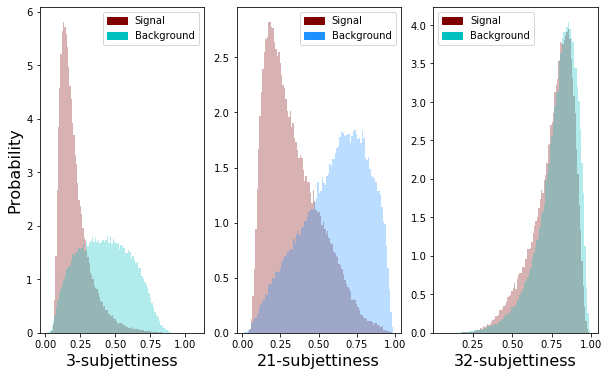

```python
fig, (ax1, ax2, ax3) = plt.subplots(1, 3)
ax1.hist(higgs['t3'][:], 100, color = 'maroon', density=True, alpha=0.3)
ax1.hist(qcd['t3'][:], 100, color = 'c', density=True, alpha=0.3)
ax1.set_xlabel('3-subjettiness', fontsize=16)
ax1.set_ylabel('Probability', fontsize=16)
maroon_patch = mpatches.Patch(color='maroon', label='Signal')
c_patch = mpatches.Patch(color='c', label='Background')
ax1.legend(handles=[maroon_patch, c_patch])

ax2.hist(higgs['t21'][:], 100, color = 'maroon', density=True, alpha=0.3)
ax2.hist(qcd['t21'][:], 100, color = 'dodgerblue', density=True, alpha=0.3)
ax2.set_xlabel('21-subjettiness', fontsize=16)
sig_patch = mpatches.Patch(color='maroon', label='Signal')
bcg_patch = mpatches.Patch(color='dodgerblue', label='Background')
ax2.legend(handles=[sig_patch, bcg_patch])

ax3.hist(higgs['t32'][:], 100, color = 'maroon', density=True, alpha=0.3)
ax3.hist(qcd['t32'][:], 100, color = 'c', density=True, alpha=0.3)
ax3.set_xlabel('32-subjettiness', fontsize=16)
maroon_patch = mpatches.Patch(color='maroon', label='Signal')
c_patch = mpatches.Patch(color='c', label='Background')
ax3.legend(handles=[maroon_patch, c_patch])
```

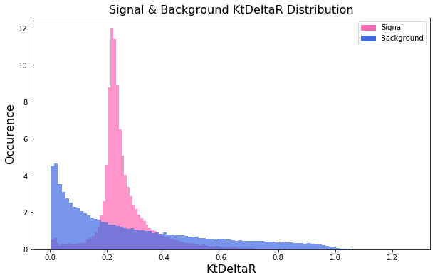

```python
plt.hist(higgs['KtDeltaR'][:], 100, color = 'hotpink', density=True, alpha=0.7)
plt.hist(qcd['KtDeltaR'][:], 100, color = 'royalblue', density=True, alpha=0.7)
plt.xlabel('KtDeltaR', fontsize=16)
plt.ylabel('Occurence', fontsize=16)
plt.title('Signal & Background KtDeltaR Distribution', fontsize=16)
sig_patch = mpatches.Patch(color='hotpink', label='Signal')
bcg_patch = mpatches.Patch(color='royalblue', label='Background')
plt.legend(handles=[sig_patch, bcg_patch])
```

From the above graphs, we can see that there are definitely some other features that could be as descriminative as the masss feature since there are features graphs that are well divided between background and signal.

SET B

Now we will try to plot these features with the optimal mass cuts.

```python
masscut_higgs = higgs[(higgs['mass'] < 130) & (higgs['mass'] > 124)]
masscut_qcd = qcd[(qcd['mass'] < 130) & (qcd['mass'] > 124)]
```

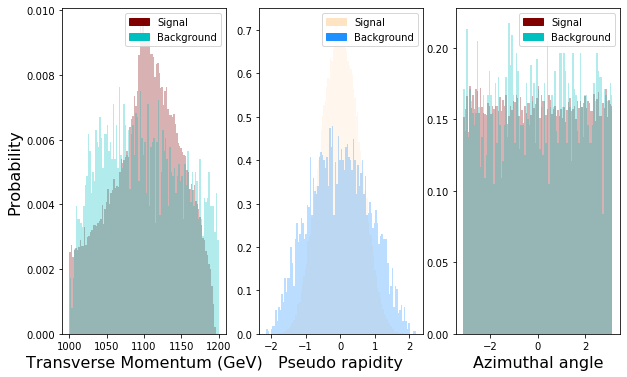

```python
fig, (ax1, ax2, ax3) = plt.subplots(1, 3)
ax1.hist(masscut_higgs['pt'][:], 100, color = 'maroon', density=True, alpha=0.3)
ax1.hist(masscut_qcd['pt'][:], 100, color = 'c', density=True, alpha=0.3)
ax1.set_xlabel('Transverse Momentum (GeV)', fontsize=16)
ax1.set_ylabel('Probability', fontsize=16)
maroon_patch = mpatches.Patch(color='maroon', label='Signal')
c_patch = mpatches.Patch(color='c', label='Background')
ax1.legend(handles=[maroon_patch, c_patch])

ax2.hist(masscut_higgs['eta'][:], 100, color = 'bisque', density=True, alpha=0.3)
ax2.hist(masscut_qcd['eta'][:], 100, color = 'dodgerblue', density=True, alpha=0.3)
ax2.set_xlabel('Pseudo rapidity', fontsize=16)
sig_patch = mpatches.Patch(color='bisque', label='Signal')
bcg_patch = mpatches.Patch(color='dodgerblue', label='Background')
ax2.legend(handles=[sig_patch, bcg_patch])

ax3.hist(masscut_higgs['phi'][:], 100, color = 'maroon', density=True, alpha=0.3)
ax3.hist(masscut_qcd['phi'][:], 100, color = 'c', density=True, alpha=0.3)
ax3.set_xlabel('Azimuthal angle', fontsize=16)
maroon_patch = mpatches.Patch(color='maroon', label='Signal')
c_patch = mpatches.Patch(color='c', label='Background')
ax3.legend(handles=[maroon_patch, c_patch])
```

From the above graphs, we can see that for features transverse momentum, pseudo rapidity, and azimuthal angle, the distribution after event selection do not have big discriminatory power. Therefore, further optimization is not required.

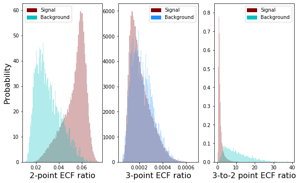

```python
fig, (ax1, ax2, ax3) = plt.subplots(1, 3)
ax1.hist(masscut_higgs['ee2'][:], 100, color = 'maroon', density=True, alpha=0.3)
ax1.hist(masscut_qcd['ee2'][:], 100, color = 'c', density=True, alpha=0.3)
ax1.set_xlabel('2-point ECF ratio', fontsize=16)
ax1.set_ylabel('Probability', fontsize=16)
maroon_patch = mpatches.Patch(color='maroon', label='Signal')
c_patch = mpatches.Patch(color='c', label='Background')
ax1.legend(handles=[maroon_patch, c_patch])

ax2.hist(masscut_higgs['ee3'][:], 100, color = 'maroon', density=True, alpha=0.3)
ax2.hist(masscut_qcd['ee3'][:], 100, color = 'dodgerblue', density=True, alpha=0.3)
ax2.set_xlabel('3-point ECF ratio', fontsize=16)
sig_patch = mpatches.Patch(color='maroon', label='Signal')
bcg_patch = mpatches.Patch(color='dodgerblue', label='Background')
ax2.legend(handles=[sig_patch, bcg_patch])

ax3.hist(masscut_higgs['d2'][:], 100, color = 'maroon', density=True, alpha=0.3)
ax3.hist(masscut_qcd['d2'][:], 100, color = 'c', density=True, alpha=0.3)
ax3.set_xlabel('3-to-2 point ECF ratio', fontsize=16)
maroon_patch = mpatches.Patch(color='maroon', label='Signal')
c_patch = mpatches.Patch(color='c', label='Background')
ax3.legend(handles=[maroon_patch, c_patch])
```

From the above graphs, after event selection, 2 Point ECF ratio and 3-to-2 Point ECF ratio still provide great discrimination power compared with the 3 point ECF ratio. Therefore, we could use further cuts to optimize the selection.

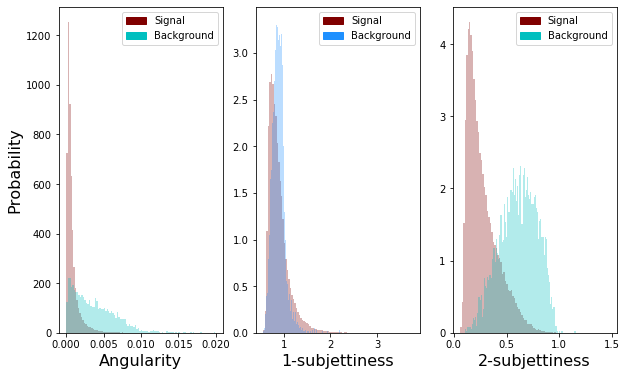

```python
fig, (ax1, ax2, ax3) = plt.subplots(1, 3)
ax1.hist(masscut_higgs['angularity'][:], 100, color = 'maroon', density=True, alpha=0.3)
ax1.hist(masscut_qcd['angularity'][:], 100, color = 'c', density=True, alpha=0.3)
ax1.set_xlabel('Angularity', fontsize=16)
ax1.set_ylabel('Probability', fontsize=16)
maroon_patch = mpatches.Patch(color='maroon', label='Signal')
c_patch = mpatches.Patch(color='c', label='Background')
ax1.legend(handles=[maroon_patch, c_patch])

ax2.hist(masscut_higgs['t1'][:], 100, color = 'maroon', density=True, alpha=0.3)
ax2.hist(masscut_qcd['t1'][:], 100, color = 'dodgerblue', density=True, alpha=0.3)
ax2.set_xlabel('1-subjettiness', fontsize=16)
sig_patch = mpatches.Patch(color='maroon', label='Signal')
bcg_patch = mpatches.Patch(color='dodgerblue', label='Background')
ax2.legend(handles=[sig_patch, bcg_patch])

ax3.hist(masscut_higgs['t2'][:], 100, color = 'maroon', density=True, alpha=0.3)
ax3.hist(masscut_qcd['t2'][:], 100, color = 'c', density=True, alpha=0.3)
ax3.set_xlabel('2-subjettiness', fontsize=16)
maroon_patch = mpatches.Patch(color='maroon', label='Signal')
c_patch = mpatches.Patch(color='c', label='Background')
ax3.legend(handles=[maroon_patch, c_patch])
```

From the above graphs, we can see that the 2-subjettiness and angularity do have some potential for further event cut, but the 1-subjettiness has a very small discrimination power. Thus, further cut is not necessary.

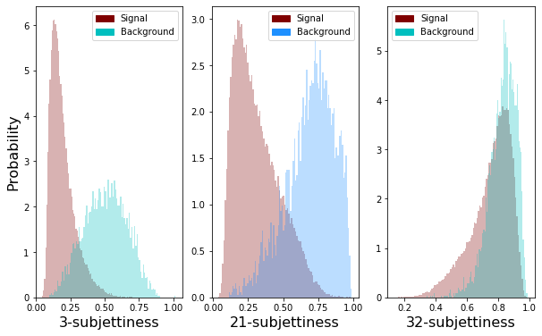

```python
fig, (ax1, ax2, ax3) = plt.subplots(1, 3)
ax1.hist(masscut_higgs['t3'][:], 100, color = 'maroon', density=True, alpha=0.3)
ax1.hist(masscut_qcd['t3'][:], 100, color = 'c', density=True, alpha=0.3)
ax1.set_xlabel('3-subjettiness', fontsize=16)
ax1.set_ylabel('Probability', fontsize=16)
maroon_patch = mpatches.Patch(color='maroon', label='Signal')
c_patch = mpatches.Patch(color='c', label='Background')
ax1.legend(handles=[maroon_patch, c_patch])

ax2.hist(masscut_higgs['t21'][:], 100, color = 'maroon', density=True, alpha=0.3)
ax2.hist(masscut_qcd['t21'][:], 100, color = 'dodgerblue', density=True, alpha=0.3)
ax2.set_xlabel('21-subjettiness', fontsize=16)
sig_patch = mpatches.Patch(color='maroon', label='Signal')
bcg_patch = mpatches.Patch(color='dodgerblue', label='Background')
ax2.legend(handles=[sig_patch, bcg_patch])

ax3.hist(masscut_higgs['t32'][:], 100, color = 'maroon', density=True, alpha=0.3)
ax3.hist(masscut_qcd['t32'][:], 100, color = 'c', density=True, alpha=0.3)
ax3.set_xlabel('32-subjettiness', fontsize=16)
maroon_patch = mpatches.Patch(color='maroon', label='Signal')
c_patch = mpatches.Patch(color='c', label='Background')
ax3.legend(handles=[maroon_patch, c_patch])
```

From these three plots, we know that 3-subjettiness and 21-subjettiness are good for further event selection since they provide a great discrimination power.

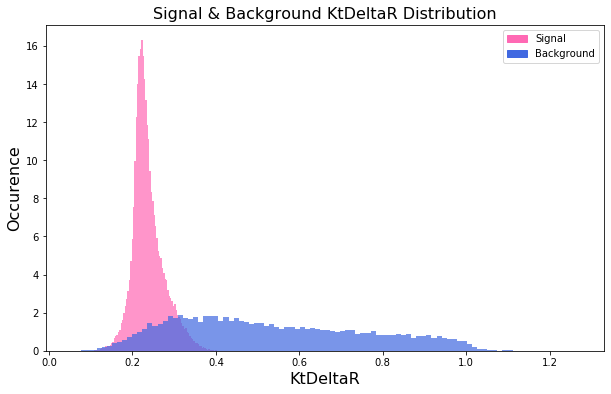

```python
plt.hist(masscut_higgs['KtDeltaR'][:], 100, color = 'hotpink', density=True, alpha=0.7)
plt.hist(masscut_qcd['KtDeltaR'][:], 100, color = 'royalblue', density=True, alpha=0.7)
plt.xlabel('KtDeltaR', fontsize=16)
plt.ylabel('Occurence', fontsize=16)
plt.title('Signal & Background KtDeltaR Distribution', fontsize=16)
sig_patch = mpatches.Patch(color='hotpink', label='Signal')
bcg_patch = mpatches.Patch(color='royalblue', label='Background')
plt.legend(handles=[sig_patch, bcg_patch])
```

The above histogram of KtDeltaR proves that further event selection could be applied since it still has a big discrinimation power after the first event cut.

To conclude, after plotting with the optimal cut, we can still see that some of the features are still descriminative, therefore, the expected siginificance can be further improved.

Problem 4

In this problem, we will find a set of feature cuts which can help you to achieve the best significance. From the above graphs, we can see features d2 and ee2 are good for further feature cuts. Therefore, we will use these two features and the same method to achieve the best significance.

```python
def ee2_cuts (bottom, top):
    higgs_cut = 100000 - (len(higgs['ee2'][bottom > higgs['ee2']]) + len(higgs['ee2'][top < higgs['ee2']]))
    qcd_cut = 100000 - (len(qcd['ee2'][bottom > qcd['ee2']]) + len(qcd['ee2'][top < qcd['ee2']]))
    higgsratio = higgs_cut / len(higgs['ee2'])
    qcdratio = qcd_cut / len(qcd['ee2'])
    N_higgs = 50 * higgsratio
    N_qcd = 2000 * qcdratio
    sig = stats.norm.isf(stats.poisson.sf(N_higgs + N_qcd,N_qcd))
    return sig
```

```python
print(ee2_cuts(0.04, 0.07))
print(ee2_cuts(0.05, 0.07))
print(ee2_cuts(0.0497, 0.0669))
```

```
1.979413387147597
2.0682759424738753
2.140607944020572
```

```python
def d2_cuts (bottom, top):
    higgs_cut = 100000 - (len(higgs['d2'][bottom > higgs['d2']]) + len(higgs['d2'][top < higgs['d2']]))
    qcd_cut = 100000 - (len(qcd['d2'][bottom > qcd['d2']]) + len(qcd['d2'][top < qcd['d2']]))
    higgsratio = higgs_cut / len(higgs['d2'])
    qcdratio = qcd_cut / len(qcd['d2'])
    N_higgs = 50 * higgsratio
    N_qcd = 2000 * qcdratio
    sig = stats.norm.isf(stats.poisson.sf(N_higgs + N_qcd,N_qcd))
    return sig
```

```python
print(d2_cuts(0, 10))
print(d2_cuts(0, 5))
print(d2_cuts(0.5, 2))
```

```
1.2964695566006892
1.4891485560717048
1.8944720104120483
```

After different cuts, we see that the best significance for 2-Point ECF ratio is 2.14 with a range of 0.0497 to 0.0669, and for 3-to-2-Point ECF ratio, the best significance is in the range 0.5 to 2 with a value of 1.894.

Compared with the significance calculated by my partner deadling with low pT data, both of my significances for ee2 and d2 are smaller than his., which are 2.96 and 8.126.

Lab 8 Pseudo-experiment data analysis

In this lab, we will conduct pseudo-experiment data analysis using the optimized event selection from previous lab 7 and hunt for the signal by using one of the pseduo-experiment dataset.

Problem 1. High luminosity data

Problem 1 A)

For this problem, we will focus on the mass, d2 and ee2 feature and plot the observed data, overlap with expected signal and background with and without event selection.

```python
import h5py
hf = h5py.File('data_highLumi_pt_1000_1200.h5', 'r')
data1 = np.array(hf.get('data/block0_values'))

hf = h5py.File('data_lowLumi_pt_1000_1200.h5', 'r')
data2 = np.array(hf.get('data/block0_values'))
hf.close()

mass_high = data1[:, 3]
mass_low = data2[:, 3]
d2_high = data1[:, 6]
d2_low = data2[:, 6]
ee2_high = data1[:, 4]
ee2_low = data2[:, 4]
```

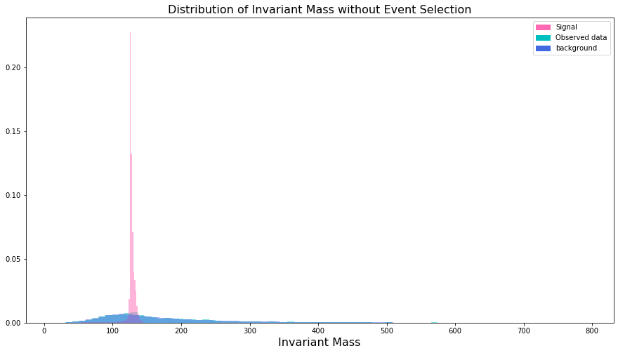

```python
fig, ax = plt.subplots(figsize=(15,8))
ax.hist(mass_high, bins = 80, color="c", alpha=0.5, density=True)
ax.hist(higgs['mass'], bins = 80, color="hotpink", alpha=0.5, density=True)
ax.hist(qcd['mass'], bins = 80, color="royalblue", alpha=0.5, density=True)
hotpink_patch = mpatches.Patch(color='hotpink', label='Signal')
c_patch = mpatches.Patch(color='c', label='Observed data')
blue_patch = mpatches.Patch(color='royalblue', label='background')
ax.legend(handles=[hotpink_patch, c_patch, blue_patch])
ax.set_xlabel('Invariant Mass', fontsize = 16)
ax.set_title('Distribution of Invariant Mass without Event Selection', fontsize = 16)
```

The above histogram is the distribution of invariant mass data without event selection. Now we will plot the same plot regarding to d2 feature.

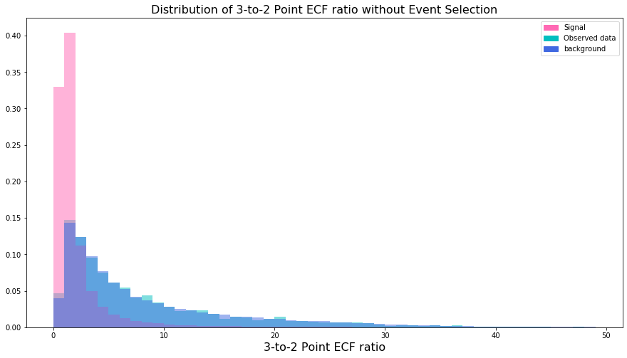

```python
fig, ax = plt.subplots(figsize=(15,8))
ax.hist(d2_high, bins = range(0, 50), color="c", alpha=0.5, density=True)
ax.hist(higgs['d2'], bins = range(0, 50), color="hotpink", alpha=0.5, density=True)
ax.hist(qcd['d2'], bins = range(0, 50), color="royalblue", alpha=0.5, density=True)
hotpink_patch = mpatches.Patch(color='hotpink', label='Signal')
c_patch = mpatches.Patch(color='c', label='Observed data')
blue_patch = mpatches.Patch(color='royalblue', label='background')
ax.legend(handles=[hotpink_patch, c_patch, blue_patch])
ax.set_xlabel('3-to-2 Point ECF ratio', fontsize = 16)
ax.set_title('Distribution of 3-to-2 Point ECF ratio without Event Selection', fontsize = 16)
```

Now we will do the same thing with 2-Point ECF ratio.

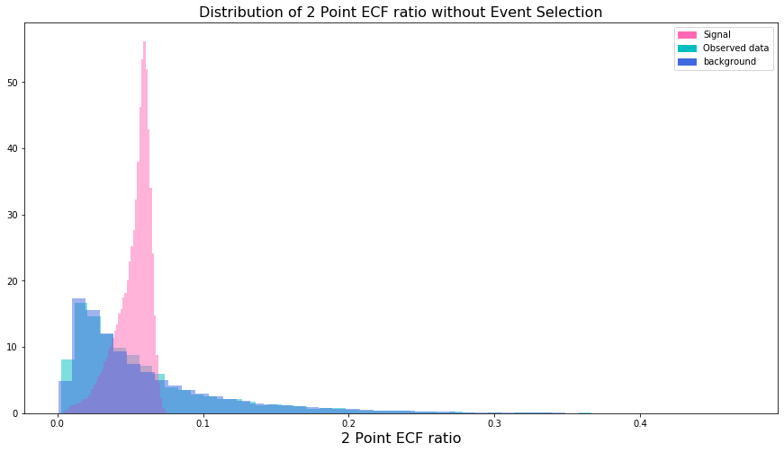

```python
fig, ax = plt.subplots(figsize=(15,8))
ax.hist(ee2_high, bins = 50, color="c", alpha=0.5, density=True)
ax.hist(higgs['ee2'], bins = 50, color="hotpink", alpha=0.5, density=True)
ax.hist(qcd['ee2'], bins = 50, color="royalblue", alpha=0.5, density=True)
hotpink_patch = mpatches.Patch(color='hotpink', label='Signal')
c_patch = mpatches.Patch(color='c', label='Observed data')
blue_patch = mpatches.Patch(color='royalblue', label='background')
ax.legend(handles=[hotpink_patch, c_patch, blue_patch])
ax.set_xlabel('2 Point ECF ratio', fontsize = 16)
ax.set_title('Distribution of 2 Point ECF ratio without Event Selection', fontsize = 16)
```

Problem 1 B)

Now, we will use the same cut with range of 124 to 130 in the previous lab to plot the observed data of invariant mass with signal and background overlapping.

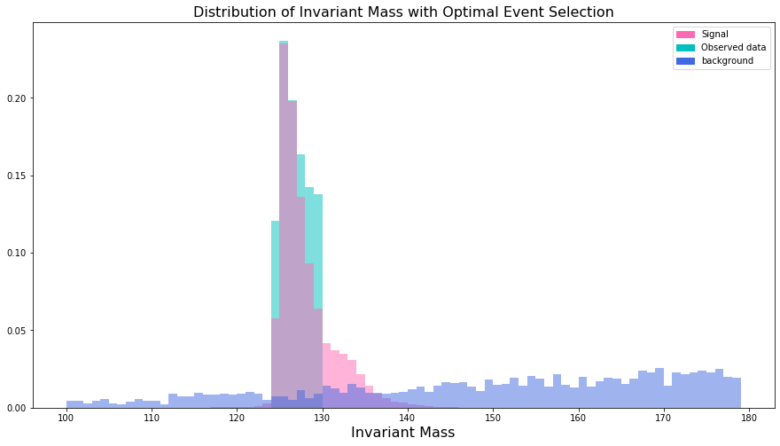

```python
masscut_highmass = mass_high[(mass_high < 130) & (mass_high > 124)]
fig, ax = plt.subplots(figsize=(15, 8))
ax.hist(masscut_highmass, bins = range(100, 180), color="c", alpha=0.5, density=True)
ax.hist(masscut_higgs['mass'], bins = range(100, 180), color="hotpink", alpha=0.5, density=True)
ax.hist(masscut_qcd['mass'], bins = range(100, 180), color="royalblue", alpha=0.5, density=True)
hotpink_patch = mpatches.Patch(color='hotpink', label='Signal')
c_patch = mpatches.Patch(color='c', label='Observed data')
blue_patch = mpatches.Patch(color='royalblue', label='background')
ax.legend(handles=[hotpink_patch, c_patch, blue_patch])
ax.set_xlabel('Invariant Mass', fontsize = 16)
ax.set_title('Distribution of Invariant Mass with Optimal Event Selection', fontsize = 16)
```

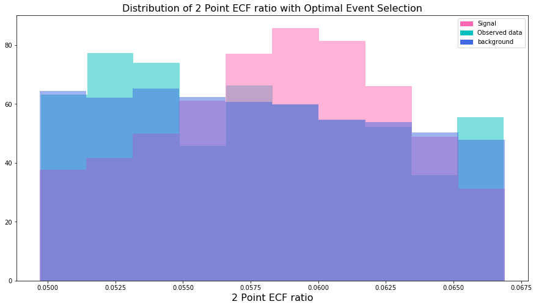

```python
masscut_highee2 = ee2_high[(ee2_high < 0.0669) & (ee2_high > 0.0497)]
masscut_higgs = higgs[(higgs['ee2'] < 0.0669) & (higgs['ee2'] > 0.0497)]
masscut_qcd = qcd[(qcd['ee2'] < 0.0669) & (qcd['ee2'] > 0.0497)]
fig, ax = plt.subplots(figsize=(15, 8))
ax.hist(masscut_highee2, color="c", alpha=0.5, density=True)
ax.hist(masscut_higgs['ee2'], color="hotpink", alpha=0.5, density=True)
ax.hist(masscut_qcd['ee2'], color="royalblue", alpha=0.5, density=True)
hotpink_patch = mpatches.Patch(color='hotpink', label='Signal')
c_patch = mpatches.Patch(color='c', label='Observed data')
blue_patch = mpatches.Patch(color='royalblue', label='background')
ax.legend(handles=[hotpink_patch, c_patch, blue_patch])
ax.set_xlabel('2 Point ECF ratio', fontsize = 16)
ax.set_title('Distribution of 2 Point ECF ratio with Optimal Event Selection', fontsize = 16)
```

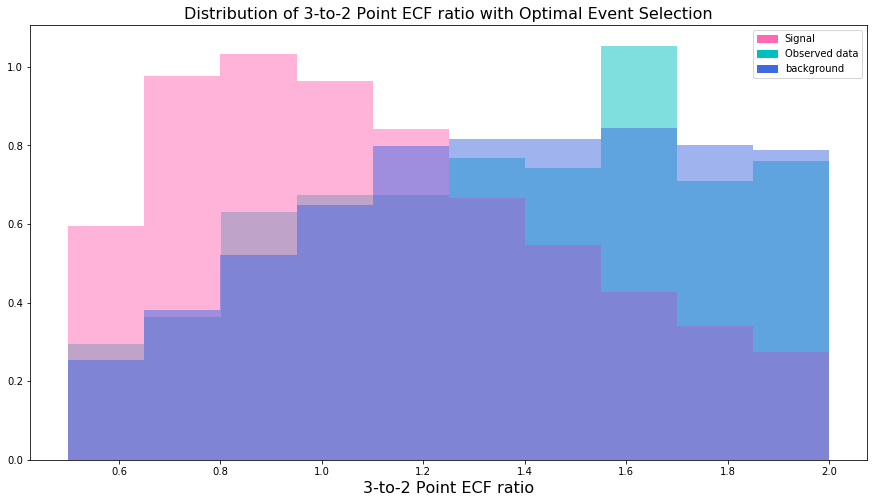

```python
masscut_highd2 = d2_high[(d2_high < 2) & (d2_high > 0.5)]
masscut_higgs = higgs[(higgs['d2'] < 2) & (higgs['d2'] > 0.5)]
masscut_qcd = qcd[(qcd['d2'] < 2) & (qcd['d2'] > 0.5)]
fig, ax = plt.subplots(figsize=(15, 8))
ax.hist(masscut_highd2, color="c", alpha=0.5, density=True)
ax.hist(masscut_higgs['d2'], color="hotpink", alpha=0.5, density=True)
ax.hist(masscut_qcd['d2'], color="royalblue", alpha=0.5, density=True)
hotpink_patch = mpatches.Patch(color='hotpink', label='Signal')
c_patch = mpatches.Patch(color='c', label='Observed data')
blue_patch = mpatches.Patch(color='royalblue', label='background')
ax.legend(handles=[hotpink_patch, c_patch, blue_patch])
ax.set_xlabel('3-to-2 Point ECF ratio', fontsize = 16)
ax.set_title('Distribution of 3-to-2 Point ECF ratio with Optimal Event Selection', fontsize = 16)
```

The above histogram is the distribution of 3-to-2 Point ECF ratio with the optimal event selection we got from previous lab, which is the rang of 0.5 to 2.

Problem 1 C)

```python
higgs_cut = len(masscut_higgs['mass'])
obs_cut = len(masscut_highmass)

higgsratio = higgs_cut / len(higgs['mass'])
obsratio = obs_cut / len(mass_high)
N_higgs = 50 * higgsratio
N_qcd = 2000 * obsratio
print("Observed invariant mass significance is", stats.norm.isf(stats.poisson.sf(N_higgs + N_qcd,N_qcd)))
```

```
Observed invariant mass significance is 3.26024045083667
```

```python
higgs_cut = len(masscut_higgs['ee2'])
obs_cut = len(masscut_highee2)

higgsratio = higgs_cut / len(higgs['ee2'])
obsratio = obs_cut / len(ee2_high)
N_higgs = 50 * higgsratio
N_qcd = 2000 * obsratio
print("Observed 2 Point ECF ratio significance is", stats.norm.isf(stats.poisson.sf(N_higgs + N_qcd,N_qcd)))
```

```
Observed 2 Point ECF ratio significance is 2.198553039952864
```

```python
higgs_cut = len(masscut_higgs['d2'])
obs_cut = len(masscut_highd2)

higgsratio = higgs_cut / len(higgs['d2'])
obsratio = obs_cut / len(d2_high)
N_higgs = 50 * higgsratio
N_qcd = 2000 * obsratio
print("Observed 3-to-2 Point ECF ratio significance is", stats.norm.isf(stats.poisson.sf(N_higgs + N_qcd,N_qcd)))
```

```
Observed 3-to-2 Point ECF ratio significance is 1.8160691570493315
```

From the above calculations, we got an observed significance for invariant mass as 3.26, which is lower than the expected significance of 3.99. The observed significance for 2 Point ECF ratio is 2.199, and it is greater than the expected value of 2.14. As of the 3-to-2 Point ECF ratio, we got an observed significance of 1.816, which is close to the expected value of 1.894 but still smaller.

Problem 2. Low luminosity data

Problem 2 A)

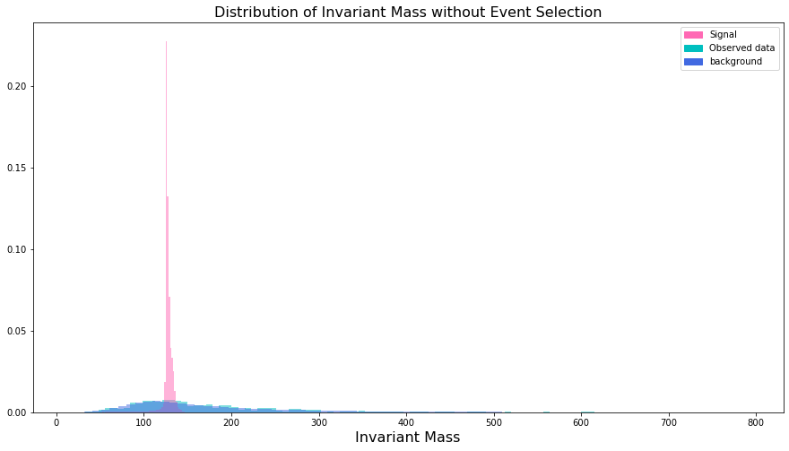

```python
fig, ax = plt.subplots(figsize=(15,8))
ax.hist(mass_low, bins = 80, color="c", alpha=0.5, density=True)
ax.hist(higgs['mass'], bins = 80, color="hotpink", alpha=0.5, density=True)
ax.hist(qcd['mass'], bins = 80, color="royalblue", alpha=0.5, density=True)
hotpink_patch = mpatches.Patch(color='hotpink', label='Signal')
c_patch = mpatches.Patch(color='c', label='Observed data')
blue_patch = mpatches.Patch(color='royalblue', label='background')
ax.legend(handles=[hotpink_patch, c_patch, blue_patch])
ax.set_xlabel('Invariant Mass', fontsize = 16)
ax.set_title('Distribution of Invariant Mass without Event Selection', fontsize = 16)
```

The above graph is the distribution of invariant mass with low luminosity and no optimal selection. Now we will plot the histogram for 2 Point ECF ratio with low luminosity.

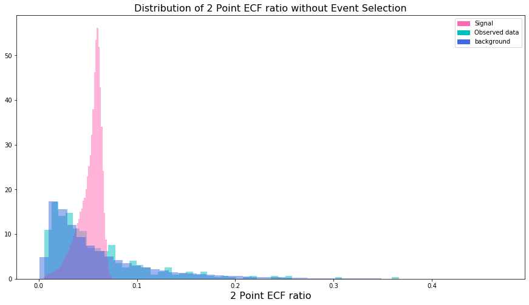

```python
fig, ax = plt.subplots(figsize=(15,8))
ax.hist(ee2_low, bins = 50, color="c", alpha=0.5, density=True)
ax.hist(higgs['ee2'], bins = 50, color="hotpink", alpha=0.5, density=True)
ax.hist(qcd['ee2'], bins = 50, color="royalblue", alpha=0.5, density=True)
hotpink_patch = mpatches.Patch(color='hotpink', label='Signal')
c_patch = mpatches.Patch(color='c', label='Observed data')
blue_patch = mpatches.Patch(color='royalblue', label='background')
ax.legend(handles=[hotpink_patch, c_patch, blue_patch])
ax.set_xlabel('2 Point ECF ratio', fontsize = 16)
ax.set_title('Distribution of 2 Point ECF ratio without Event Selection', fontsize = 16)
```

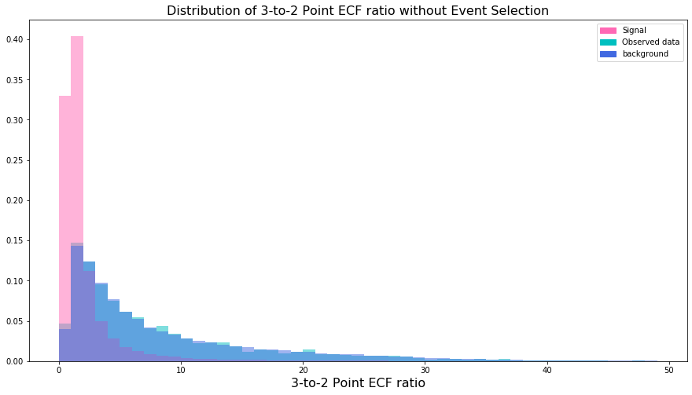

```python
fig, ax = plt.subplots(figsize=(15,8))
ax.hist(d2_high, bins = range(0, 50), color="c", alpha=0.5, density=True)
ax.hist(higgs['d2'], bins = range(0, 50), color="hotpink", alpha=0.5, density=True)
ax.hist(qcd['d2'], bins = range(0, 50), color="royalblue", alpha=0.5, density=True)
hotpink_patch = mpatches.Patch(color='hotpink', label='Signal')
c_patch = mpatches.Patch(color='c', label='Observed data')
blue_patch = mpatches.Patch(color='royalblue', label='background')
ax.legend(handles=[hotpink_patch, c_patch, blue_patch])
ax.set_xlabel('3-to-2 Point ECF ratio', fontsize = 16)
ax.set_title('Distribution of 3-to-2 Point ECF ratio without Event Selection', fontsize = 16)
```

Problem 2 B)

Now we will plot the distribution of observed data with optimal event selection that are same to the problem 1.

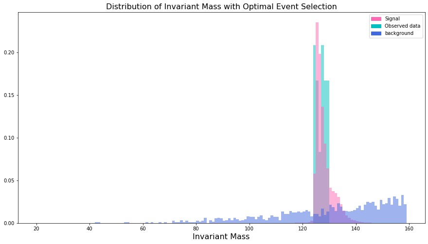

```python
masscut_lowmass = mass_low[(mass_low < 130) & (mass_low > 124)]
fig, ax = plt.subplots(figsize=(15, 8))
ax.hist(masscut_lowmass, bins = range(20, 160), color="c", alpha=0.5, density=True)
ax.hist(masscut_higgs['mass'], bins = range(20, 160), color="hotpink", alpha=0.5, density=True)
ax.hist(masscut_qcd['mass'], bins = range(20, 160), color="royalblue", alpha=0.5, density=True)
hotpink_patch = mpatches.Patch(color='hotpink', label='Signal')
c_patch = mpatches.Patch(color='c', label='Observed data')
blue_patch = mpatches.Patch(color='royalblue', label='background')
ax.legend(handles=[hotpink_patch, c_patch, blue_patch])
ax.set_xlabel('Invariant Mass', fontsize = 16)
ax.set_title('Distribution of Invariant Mass with Optimal Event Selection', fontsize = 16)
```

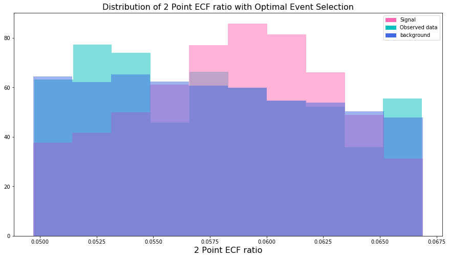

```python
masscut_lowee2 = ee2_low[(ee2_low < 0.0669) & (ee2_low > 0.0497)]
masscut_higgs = higgs[(higgs['ee2'] < 0.0669) & (higgs['ee2'] > 0.0497)]
masscut_qcd = qcd[(qcd['ee2'] < 0.0669) & (qcd['ee2'] > 0.0497)]
fig, ax = plt.subplots(figsize=(15, 8))
ax.hist(masscut_highee2, color="c", alpha=0.5, density=True)
ax.hist(masscut_higgs['ee2'], color="hotpink", alpha=0.5, density=True)
ax.hist(masscut_qcd['ee2'], color="royalblue", alpha=0.5, density=True)
hotpink_patch = mpatches.Patch(color='hotpink', label='Signal')
c_patch = mpatches.Patch(color='c', label='Observed data')
blue_patch = mpatches.Patch(color='royalblue', label='background')
ax.legend(handles=[hotpink_patch, c_patch, blue_patch])
ax.set_xlabel('2 Point ECF ratio', fontsize = 16)
ax.set_title('Distribution of 2 Point ECF ratio with Optimal Event Selection', fontsize = 16)
```

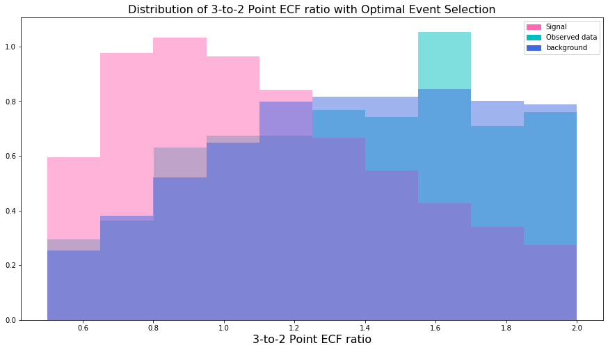

```python
masscut_lowd2 = d2_low[(d2_low < 2) & (d2_low > 0.5)]
masscut_higgs = higgs[(higgs['d2'] < 2) & (higgs['d2'] > 0.5)]
masscut_qcd = qcd[(qcd['d2'] < 2) & (qcd['d2'] > 0.5)]
fig, ax = plt.subplots(figsize=(15, 8))
ax.hist(masscut_highd2, color="c", alpha=0.5, density=True)
ax.hist(masscut_higgs['d2'], color="hotpink", alpha=0.5, density=True)
ax.hist(masscut_qcd['d2'], color="royalblue", alpha=0.5, density=True)
hotpink_patch = mpatches.Patch(color='hotpink', label='Signal')
c_patch = mpatches.Patch(color='c', label='Observed data')
blue_patch = mpatches.Patch(color='royalblue', label='background')
ax.legend(handles=[hotpink_patch, c_patch, blue_patch])
ax.set_xlabel('3-to-2 Point ECF ratio', fontsize = 16)
ax.set_title('Distribution of 3-to-2 Point ECF ratio with Optimal Event Selection', fontsize = 16)
```

Problem 2 C)

In this part, we will evaluate observed significance for low luminosity data and compare your results to expectation. The method and formula we are going to use in this section is same as the previous one.

```python
higgs_cut = len(masscut_higgs['mass'])
obs_cut = len(masscut_lowmass)

higgsratio = higgs_cut / len(higgs['mass'])
obsratio = obs_cut / len(mass_low)
N_higgs = 50 * higgsratio
N_qcd = 2000 * obsratio
print("Observed invariant mass significance with low luminosity is", stats.norm.isf(stats.poisson.sf(N_higgs + N_qcd,N_qcd)))
```

```
Observed invariant mass significance with low luminosity is 3.2928127312443487
```

```python
higgs_cut = len(masscut_higgs['ee2'])
obs_cut = len(masscut_lowee2)

higgsratio = higgs_cut / len(higgs['ee2'])
obsratio = obs_cut / len(ee2_low)
N_higgs = 50 * higgsratio
N_qcd = 2000 * obsratio
print("Observed 2 Point ECF ratio significance with low luminosity is", stats.norm.isf(stats.poisson.sf(N_higgs + N_qcd,N_qcd)))
```

```
Observed 2 Point ECF ratio significance with low luminosity is 2.313990454112642
```

```python
higgs_cut = len(masscut_higgs['d2'])
obs_cut = len(masscut_lowd2)

higgsratio = higgs_cut / len(higgs['d2'])
obsratio = obs_cut / len(d2_low)
N_higgs = 50 * higgsratio
N_qcd = 2000 * obsratio
print("Observed 3-to-2 Point ECF ratio significance with low luminosity is", stats.norm.isf(stats.poisson.sf(N_higgs + N_qcd,N_qcd)))
```

```
Observed 3-to-2 Point ECF ratio significance with low luminosity is 1.883804857932649
```

From the above calculation, we got the observed significance for invariant mass with low luminosity as 3.293, which is lower than our expected significance but higher than the observed significance for invariant mass with high luminosity. The observed significance for 2 Point ECF ratio with low luminosity is 2.314. It is higher than both the expected value and the observed significance for 2 Point ECF ratio with high luminosity. At last, our calculated observed significance for 3-to-2 Point ECF ratio with low luminosiy is 1.884, which is higher than the significance for this feature with high luminosity and lower than the expected significance. However, it is really close to the expected value with a difference of 0.01.

Problem 3. 95% Confidence Level of signal yields

In the low luminosity data, the observed significance is less than 5 𝜎. Therefore, in this problem, we will calculate the 95% confidence level upper limit of signal yield with low luminosity data for all the features mentioned in previous two problems, mass, ee2, and d2.

Problem 3 A)

We will first evaluate the expected 95% confidence level upper limit of the three features. We do this by first calculating the mean of our datastes and then finding the standard error of the mean.

```python
from scipy.stats import sem, t
confidence = 0.95

n = len(higgs['mass'])
m = np.mean(higgs['mass'])
std_err = sem(higgs['mass'])
h = std_err * t.ppf((1 + confidence) / 2, n - 1)

n2 = len(higgs['ee2'])
m2 = np.mean(higgs['ee2'])
std_err2 = sem(higgs['ee2'])
h2 = std_err2 * t.ppf((1 + confidence) / 2, n2 - 1)

n3 = len(higgs['d2'])
m3 = np.mean(higgs['d2'])
std_err3 = sem(higgs['d2'])
h3 = std_err3 * t.ppf((1 + confidence) / 2, n3 - 1)

print("The expected 95% confidence level upper limit of invariant mass is", m + h)
print("The expected 95% confidence level upper limit of 2 Point ECF ratio is", m2 + h2)
print("The expected 95% confidence level upper limit of 3-to-2 Point ECF ratio is", m3 + h3)
```

```
The expected 95% confidence level upper limit of invariant mass is 126.7159451607726
The expected 95% confidence level upper limit of 2 Point ECF ratio is 0.05237225032596828
The expected 95% confidence level upper limit of 3-to-2 Point ECF ratio is 2.1534636432841454
```

Problem 3 B)

Then, we will evaluate the observed 95% confidence level upper limit of these three features with low luminosity.

```python
n = len(mass_low)
m = np.mean(mass_low)
std_err = sem(mass_low)
h = std_err * t.ppf((1 + confidence) / 2, n - 1)

n2 = len(ee2_low)
m2 = np.mean(ee2_low)
std_err2 = sem(ee2_low)
h2 = std_err2 * t.ppf((1 + confidence) / 2, n2 - 1)

n3 = len(d2_low)
m3 = np.mean(d2_low)
std_err3 = sem(d2_low)
h3 = std_err3 * t.ppf((1 + confidence) / 2, n3 - 1)

print("The observed 95% confidence level upper limit of invariant mass is", m + h)
print("The observed 95% confidence level upper limit of 2 Point ECF ratio is", m2 + h2)
print("The observed 95% confidence level upper limit of 3-to-2 Point ECF ratio is", m3 + h3)
```

```
The observed 95% confidence level upper limit of invariant mass is 179.743391977059
The observed 95% confidence level upper limit of 2 Point ECF ratio is 0.06303798770337593
The observed 95% confidence level upper limit of 3-to-2 Point ECF ratio is 8.803045573793419
```

Problem 3 C)

Evalute the 1 𝜎 uncertainty of the expected 95% confidence level upper limit.

```python
mass = 126.7159451607726
ee2 = 0.0523
d2 = 2.1534636432841454
sig = 1
prob= stats.norm.sf(sig)
print("The upper bound of 1𝜎 uncertainty of the expected 95% confidence level upper limit of invariant mass is", stats.poisson.isf(prob,mass))
print("The lower bound of 1𝜎 uncertainty of the expected 95% confidence level upper limit of invariant mass is", stats.poisson.ppf(prob, mass))
print("The upper bound of 1𝜎 uncertainty of the expected 95% confidence level upper limit of 2 Point ECF ratio is", stats.poisson.isf(prob, ee2))
print("The lower bound of 1𝜎 uncertainty of the expected 95% confidence level upper limit of 2 Point ECF ratio is", stats.poisson.ppf(prob, ee2))
print("The upper bound of 1𝜎 uncertainty of the expected 95% confidence level upper limit of 3-to-2 Point ECF ratio is", stats.poisson.isf(prob, d2))
print("The lower bound of 1𝜎 uncertainty of the expected 95% confidence level upper limit of 3-to-2 Point ECF ratio is", stats.poisson.ppf(prob, d2))
```

```
The upper bound of 1𝜎 uncertainty of the expected 95% confidence level upper limit of invariant mass is 138.0
The lower bound of 1𝜎 uncertainty of the expected 95% confidence level upper limit of invariant mass is 115.0
The upper bound of 1𝜎 uncertainty of the expected 95% confidence level upper limit of 2 Point ECF ratio is 0.0
The lower bound of 1𝜎 uncertainty of the expected 95% confidence level upper limit of 2 Point ECF ratio is 0.0
The upper bound of 1𝜎 uncertainty of the expected 95% confidence level upper limit of 3-to-2 Point ECF ratio is 4.0
The lower bound of 1𝜎 uncertainty of the expected 95% confidence level upper limit of 3-to-2 Point ECF ratio is 1.0
```